# BDA assignments

# Assingment 2

```r
# To install aaltobda, see the General information in the assignment.
library(aaltobda)
```

# Exercise 1

```r
algae <- get(data("algae"))
n <- length(algae)
y <- sum(algae)
a <- 2
b <- 10
```

The model used in this excercise is

$$p(\pi) \sim Beta(2, 10) \\
p(y \mid \pi) \sim Binom(n, y, \pi)$$

and the data are

```r
table(algae)
```

```
algae
  0   1
230  44
```

## a)

It is easy to see that the following holds:

$$p(\pi) \propto \pi^{\alpha} ( 1 - \pi)^{\beta}, \\
p(y \mid \pi) \propto \pi^{y} ( 1 - \pi)^{(n - y)}, \\
p( \pi \mid y) \propto \pi^{y + \alpha} ( 1 - \pi)^{(n - y + \beta)},$$

where the posterior has the form of the Beta distribution with parameters $\alpha + y$ and $n -y + \beta$.

In this case

- $n$ = 274
- $y$ = = 44
- $\alpha$ = 2
- $\beta$ = 10

## b)

The expectation of the beta distribution with parameters $\alpha$ and $\beta$ is $\alpha / (\alpha + \beta)$.

```r
# parameters of beta posterior with beta prior a, b and bibomial likelihood
# with data x
betabin_posterior <- function(a, b, x) {
  n <- length(x)
  y <- sum(x)
  c("a" = a + y, "b" = b + n - y)
}
beta_point_est <- function(prior_alpha, prior_beta, data) {
  th <- betabin_posterior(prior_alpha, prior_beta, data)
  th["a"] / (th["a"] + th["b"])
}
```

In the case of $p( \pi \mid y)$, the expectation corresponds to

```r
beta_point_est(a, b, algae)
```

```
        a
0.1608392
```

A 90% posterior interval can be obtained from the quantiles of the posterior Beta distribution:

```r
beta_interval <- function(prior_alpha, prior_beta, data, prob  = 0.9) {
  th <- betabin_posterior(prior_alpha, prior_beta, data)
  q1 <- (1 - prob) / 2
  q2 <- prob + q1
  qbeta(c(q1, q2), th["a"], th["b"])
}

beta_interval(a, b, algae, 0.9)
```

```
[1] 0.1265607 0.1978177
```

## c)

We can use the beta cumulative distribution function to evaluate the probability $P(\pi < 0.2 \mid y) = F_{\pi \mid y}(0.2)$.

In this case, the probability is

```r
beta_low <- function(prior_alpha, prior_beta, data, pi_0 = 0.2) {
  th <- betabin_posterior(prior_alpha, prior_beta, data)
  pbeta(pi_0, th["a"], th["b"])
}
beta_low(2, 10, algae, 0.2)
```

```
[1] 0.9586136
```

## d)

We assume the measurements $y_i$ are independent and idetically distributed.

## e)

```r
plot_beta_posterior <- function(a, b, data) {
  th <- betabin_posterior(a,b,data)
  x <- seq(0, 1, by = 0.001)
  y <- dbeta(x, th["a"], th ["b"])
  plot(x, y, xlim = c(0, 1), ylim = c(0, 20), type = "l",
       xlab = "pi", ylab = "Density")
  title(paste0("a =", a, " b=", b, " y=", sum(data), " n=", length(data)))
}
```

There is quite a lot of data so reasonably uninformative or vague priors do not have a significant effect on the posterior. A very informative prior will however affect inference.

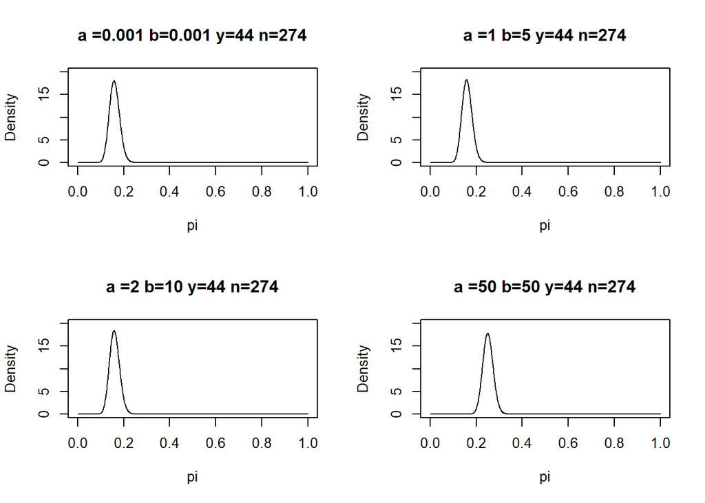

```r
par(mfrow = c(2,2))
plot_beta_posterior(0.001,0.001, algae)
plot_beta_posterior(1,5, algae)
plot_beta_posterior(2,10, algae)
plot_beta_posterior(50,50, algae)
```

# Assignment 3

# Exercise 1

## Data

```r
y <- get(data("windshieldy1"))
head(y)
```

```
[1] 13.357 14.928 14.896 15.297 14.820 12.067
```

## Model

Prior is uniform on $(\mu, log(sigma))$, i.e.:

$$p(\mu, \sigma) \sim 1/\sigma$$

Likelihood is

$$p(y \mid \mu, \sigma^2) \sim N(\mu, \sigma^2)$$

The interest is in the parameter $\mu$ for which the marginal posterior distribution is the $t_{n−1}(y, s^2/n)$ density (BDA, page 66)

$$p(\mu \mid y) \sim t_{n−1}(\bar{y}, s^2/n), \\
s^2 = \frac{1}{n-1} \sum_{i, .., n} (y_i - \bar{y})^2$$

## a)

A point estimate can be derived from the expectation of the marginal posterior distribution of $\mu$, which in this case is $\bar{y}$

```r
mu_point_est <- function(data) {
  mean(data)
}

mu_point_est(y)
```

```
[1] 14.61122
```

A credible interval can be derived from the tails of the student-t distribution with the appropriate degrees of freedom, location and scale, which are $n-1$, $\bar{y}$ and $s/\sqrt{n}$, respectively.

```r
mu_interval <- function(data, prob = 0.95) {
  q1 <- (1-prob)/2
  q2 <- 1 - q1
  mean <- mean(data)
  n <- length(data)
  df <- n -1
  scale <- sd(data) / sqrt(n)
  qtnew(c(q1, q2), df = df, mean = mean, scale = scale)
}

mu_interval(y)
```

```
[1] 13.47808 15.74436
```

## b)

The predictive distribution for a new oberservation is a t distribution with location $\bar{y}$, scale $s \cdot \sqrt{1 + 1/n }$, and $n − 1$ degrees of freedom (BDA, page 66).

$$p(\tilde{y} | y) \sim t_{n-1}(\bar{y}, s^2(1 + 1/n))$$

The point estimate is the same as with the posterior distribution.

```r
mu_pred_point_est <- function(data) {
  mu_point_est(data)
}
```

The uncertainty in the predictive distribution concerns a new observation rather than the expectation, so the credible interval is quite different. Otherwise the interval is derived similarily to the posterior credibel interval for $\mu$.

```r
mu_pred_interval <- function(data, prob = 0.95) {
  q1 <- (1-prob)/2
  q2 <- 1 - q1
  mean <- mean(data)
  n <- length(data)
  df <- n -1
  scale <- sqrt(1 + 1/n)*sd(data)
  qtnew(c(q1, q2), df = df, mean = mean, scale = scale)
}

mu_pred_interval(y)
```

```
[1] 11.02792 18.19453
```

The density of the predictive distribution is shown below.

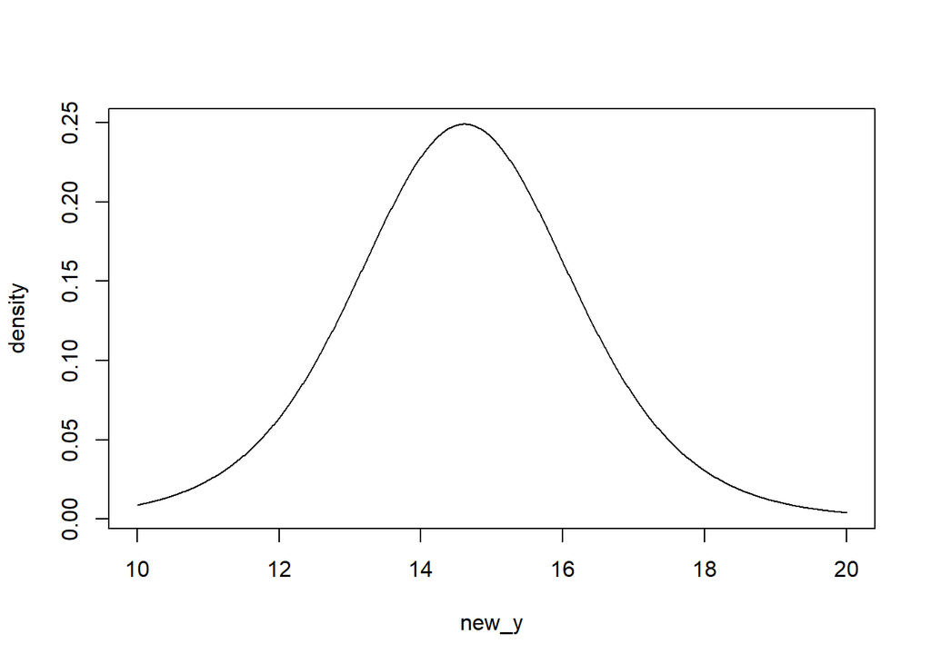

```r
# the density of the predictive distribution
y_pred_dens <- function(x, data = y) {
    mean <- mean(data)
  n <- length(data)
  df <- n -1
  scale <- sqrt(1 + 1/n)*sd(data)
  dtnew(x, df = df, mean = mean, scale = scale)
}

new_y <- seq(10, 20, by = 0.01)
density <- y_pred_dens(new_y)
plot(new_y, density, type = "l")
```

# Exercise 2

A group of patients was randomly assigned to treatment and control groups: out of 674 patients receiving the control, 39 died, and out of 680 receiving the treatment, 22 died.

## Data

```r
# control
n0 <- 674
y0 <- 39

# treatment
n1 <- 680
y1 <- 22
```

## Model

We use a weakly informative prior, using the overall proportions of successes and failures in the two groups as hyperparameters for a beta distribution, for both $p_0$ and $p_1$. The information in the prior distribution corresponds to a single observation. As there are a lot of data from both groups, the effect of any weakly informative prior will be unsignificant to the inference.

$$p(p_0) \sim Beta(0.05, 0.95) \\
p(p_1) \sim Beta(0.05, 0.95)$$

Likelihood

$$p(y0 \mid p0) \sim Binom(n0, y0) \\
p(y1 \mid p1) \sim Binom(n1, y1)$$

The marginal posterior distributions for $p0$ and $p1$ are

$$p(p_0 \mid y0) \sim Beta(y0 + 0.05, n0 - y0 + 0.95) \\
p(p_1 \mid y1) \sim Beta(y1 + 0.05, n1 - y1 + 0.95)$$

## a)

We are interested in the posterior distribution of the odds ratio, defined as

$$OR = \frac{p_1 / (1-p_1)}{p_0 / (1 - p_0)}.$$

### Conjugate approach

We can simulate values from the posterior distribution of OR by simulating values from the posterior distributions of $p_0$ and $p_1$ and applying the definition of OR to the samples.

```r
OR <- function(p0, p1) {
  odds0 <- p0 / (1 - p0)
  odds1 <- p1 / (1 - p1)
  odds1 / odds0
}
```

```r
# simulate values from the posteriors of p0 and p1

# hyperparameters
a <- 0.05
b <- 0.95

# posterior samples
N <- 10000
set.seed(4711)
p0 <- rbeta(N, a + y0, b + (n0-y0))
p1 <- rbeta(N, a + y1, b + (n1 - y1))
```

A point estimate for OR can be derived from the mean of the samples.

```r
posterior_odds_ratio_point_est  <- function(p0, p1) {
  or <- OR(p0, p1)
  mean(or)
}
posterior_odds_ratio_point_est(p0, p1)
```

```
[1] 0.5608043
```

A credible interval can be derived from the sample quantiles.

```r
 posterior_odds_ratio_interval <- function(p0, p1, prob = 0.95) {
   or <- OR(p0, p1)
   q1 <- (1-prob) / 2
   q2 <- 1 - q1
   quantile(or, probs = c(q1, q2))
 }

posterior_odds_ratio_interval(p0, p1)
```

```
     2.5%     97.5%
0.3117023 0.9179675
```

### Logistic regression approach

The Odds ratio can also be estimated using a logistic regression model. Let $p_j = E[y_j] = P(y_j = 1)$, where $j \in \{\text{control}, \text{treatment} \}$. Then let

$$logit(p_j) = \alpha + \beta \cdot x_j,$$

where $x_j$ is $0$ for the control group and $1$ for the treatment group, and $logit(p) = log(p / (1 - p))$.

#### Estimation

We learn the parameters of the logistic regression model by defining the model in STAN. The interest is in the exponent of the parameter $\beta$ which is the odds ratio of interest.

```stan
// STAN simple logistic regression
data {
int<lower = 1> N; // number of obs (groups)
int<lower = 0> n[N]; // trials for each group
int<lower = 0> y[N]; // successes for each group
vector[N] x; //  explanatory variable (e.g. group indicagtor)
}

parameters {
real alpha;
real beta;
}


model {
// priors
beta ~ normal(0, 4);
alpha ~ normal(-3, 4); // rare event

// likelihood
y ~ binomial_logit(n, alpha + beta * x);
}

generated quantities {
real<lower = 0> OR = exp(beta);
}
```

```r
# Learn the parameters by sampling from the posterior(s)
n <- c(n0, n1)
y <- c(y0, y1)
x <- c(0, 1)
N <- length(y)
fit <- rstan::sampling(model,
                       iter = 10000,
                       data = list(n = n,
                                   y = y,
                                   N = N,
                                   x = x))
```

#### Posterior distribution for the Odds ratio

```r
or <- extract(fit, pars ="OR")$OR
```

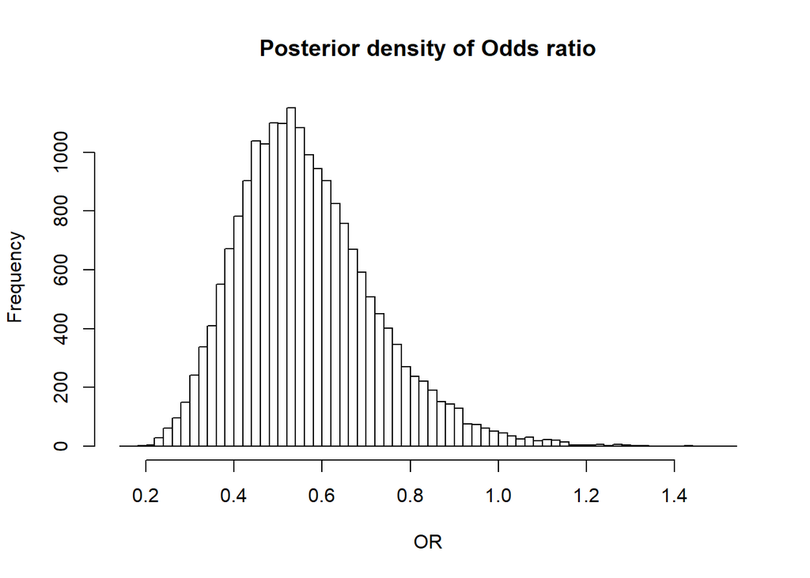

```r
hist(or,
     breaks = 50,
     main = "Posterior density of Odds ratio",
     xlab = "OR")
```

The point estimate is

```r
mean(or)
```

```
[1] 0.5660032
```

An interval estimate is very similar to the one obtained earlier using the conjugate aproach:

```r
quantile(or, p = c(0.025,0.975))
```

```
     2.5%     97.5%
0.3146189 0.9256469
```

## b)

See the model description in the beginning of the exercise for a brief sensitivity discussion.

# Exercise 3

Two production lines for windshields, with independent data samples from each.

```r
y1 <- get(data("windshieldy1"))
y2 <- get(data("windshieldy2"))
```

A summary of data from production line 1:

```r
summary(y1)
```

```
   Min. 1st Qu.  Median    Mean 3rd Qu.    Max.
  12.07   13.87   14.82   14.61   14.93   17.45
```

A summary of data from production line 2:

```r
summary(y2)
```

```
   Min. 1st Qu.  Median    Mean 3rd Qu.    Max.
  14.21   15.23   15.88   15.82   16.01   17.25
```

We assume that the samples come from two normal distributions with unknown means $\mu_1$ and $\mu_2$ and unkown standard deviations $\sigma_1$ and $\sigma_2$.

## Model

If we choose to use a uniform prior for the means and standard deviations, then the model for both production lines is identical to the model defined in the first exercise and the posterior distributions are t distributions.

## a)

```r
t_posterior <- function(y, N = 5000) {
  n <- length(y)
  mean <- mean(y)
  scale <- sd(y) / sqrt(n)
  df <- n - 1
  list(df = df,
       mean = mean,
       scale = scale,
       n = N)
}
s1 <- do.call("rtnew", t_posterior(y1))
s2 <- do.call("rtnew", t_posterior(y2))
mu_d <- s1 - s2
```

The point estimate for $\mu_d = \mu_1 - \mu_2$ is

```r
mean(mu_d)
```

```
[1] -1.212622
```

A 90% credible interval is:

```r
quantile(mu_d, p = c(0.05, 0.95))
```

```
        5%        95%
-2.2391793 -0.1915628
```

A histogram of the posterior is

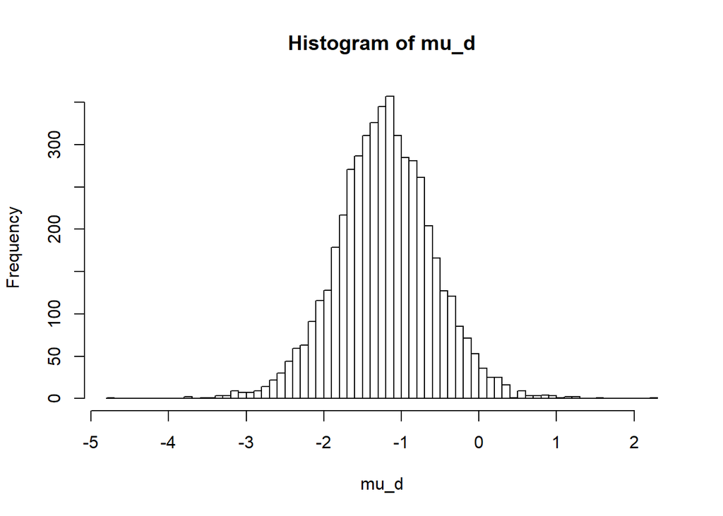

```r
hist(mu_d, breaks = 50)
```

The (posterior) probability that $mu_1 > mu_2$ is

```r
sum(mu_d > 0) / length(mu_d)
```

```
[1] 0.0264
```

## b)

Addressing the question literally, for the means $\mu_1$ and $\mu_2$ to be exactly the same, the two production lines should be identical, i.e. they should be the same production line, in which case of course $\mu_1 = \mu_2$ (with probability one).

However, even if the production lines were identical, the posterior distributions for $\mu_1$ and $\mu2$ would be identical with probability zero, unless the number of data points are infinite. From a practical point of view, however, the posterior distributions could be identical, due to the discrete nature of measurement.

If the two production lines are not identical, the posterior distributions for $\mu_1$ and $\mu_2$ should be different and $\mu_d = 0$ with probability zero. However, in practise the two posteriors could still be identical, due to discrete measurements.

# Assignment 4

# Loaded packages

Below are examples of how to load packages that are used in the assignment

```r
# To install aaltobda, see the General information in the assignment.
library(aaltobda)
```

# Exercise 1

## a)

The model used in the assignment is

$$\alpha \sim N(0, 2) \\
\beta \sim N(10,10) \\
cor(alpha, beta) = 0.6,$$

which is equivalent with

$$(\alpha, \beta) \sim N(
\begin{pmatrix}0 \\ 10\end{pmatrix},
\begin{pmatrix}2^2 & 12\\12 & 10^2\end{pmatrix})$$

## b)

*Report the mean as well as 5 % and 95 % quantiles separately for both $\alpha$ and $\beta$. Report also the Monte Carlo standard errors (MCSEs) for the mean and quantile estimates. Report as many digits for the mean and quantiles as the MCSEs allow.*

With S draws, the MCSE for $E[\theta]$ is $\sqrt{Var(\theta) / S}$. Here, $S = 4000$. The MCSE estimates are

```r
y <- get(data("bioassay_posterior"))
sqrt(sapply(y, "var") / 4000)
```

```
     alpha       beta
0.01482435 0.07560016
```

```r
digits <- function(x, n)
  format(round(x, n), nsmall = n)
```

The rounded estimate for alpha, with sifgnificant digits not subject to simulation error is

```r
alpha_signif <- 1
digits(mean(y$alpha),alpha_signif)
```

```
[1] "1.0"
```

The rounded estimate for beta, with sifgnificant digits not subject to simulation error is

```r
beta_signif <- 1
digits(mean(y$beta),beta_signif)
```

```
[1] "10.6"
```

## c)

Denote by $g$ the prior distribution which is also the approximating distribution. Denote by $L$ the likelihood and by $q(\theta) = g(\theta) L(\theta)$ the target distribution (the posterior). The weights for the importance ratios are defined as

$$w(\theta) = q(\theta) / g(\theta) \\
w(\theta) = g(\theta) L(\theta) / g(\theta) \\
w(\theta) = L(\theta)$$
and so the weights are simply given my the likelihood.

```r
df <- get(data("bioassay"))

log_importance_weights <- function(alpha, beta) {
  bioassaylp(a = alpha,
             b = beta,
             x = df$x,
             y = df$y,
             n = df$n)
}
```

## d)

Below is a function for computing normalized importance ratios from the unnormalized log ratios in c). In other words, we exponentiate the log ratios and scale them such that they sum to one.

```r
normalized_importance_weights <- function(alpha, beta) {
  lw <- log_importance_weights(alpha, beta)
  w <- exp(lw)
  w / sum(w)
}
```

## e)

We draw 4000 samples from the prior distribution of $(\alpha, \beta)$, which is the bivariate normal distribution specified earlier.

```r
mu <- c(0, 10)
S <- matrix(c(2^2, 2*10*0.6,
              2*10*0.6, 10^2 ),
            ncol = 2)

x <- rmvnorm(4000, mu, S)
```

The sample means should be aproximately 0 and 10.

```r
apply(x, 2, "mean")
```

```
[1]  0.07194939 10.13079916
```

The sample standard deviations should be aproximately 2 and 10.

```r
apply(x, 2, "sd")
```

```
[1] 1.967005 9.975277
```

The sample correlation should be aproximately 0.6.

```r
cor(x[, 1], x[, 2])
```

```
[1] 0.5921984
```

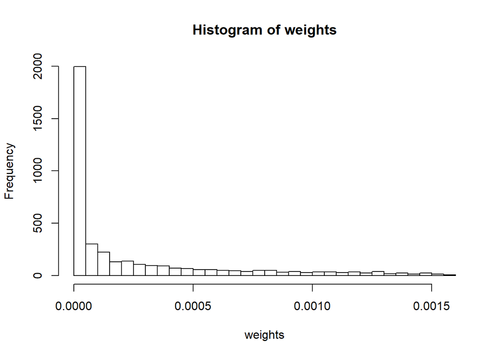

```r
alpha <- x[, 1]
beta <- x[, 2]
weights <- normalized_importance_weights(alpha, beta)
hist(weights, breaks = 50)
```

## f)

We define the effective sample size as in BDA equation 10.4.

```r
S_eff <- function(alpha, beta) {
  wnorm <- normalized_importance_weights(alpha, beta)
  1 / sum(wnorm**2)
}


round(S_eff(alpha, beta))
```

```
[1] 1216
```

## g)

*Explain the computation of the effective sample size.*

The idea of the computation is that when there are big relative differences in the weights, resulting in some of the normalized weight to be much larger than others, then the effective sample size is smaller. When all of the weights are equal (the proposal mathes the target perfectly) then the effective sample size is the number of proposal draws. The histogram in e) shows that there are differences in the weights and the effective sample size is far from the number of proposals.

## h)

Below is function for computing the posterior mean using importance sampling, and the mean computed using 4000 draws from the prior (proposal).

```r
posterior_mean <- function(alpha, beta) {
  w <- log_importance_weights(alpha, beta)
  w <- exp(w)
  a <- weighted.mean(alpha, w)
  b <- weighted.mean(beta, w)
  c(a,b)
}

theta_post <- posterior_mean(alpha, beta)
theta_post
```

```
[1]  0.9885853 10.7467002
```

We now compute the MCSE and report the estimates accounting for the simulation error.

```r
w <- log_importance_weights(alpha, beta)
w <- exp(w)
e_a <- weighted.mean(alpha, w)
e_b <- weighted.mean(beta, w)

e2_a <- weighted.mean(alpha**2, w)
e2_b <- weighted.mean(beta**2, w)

var_a <-  e2_a - e_a**2
var_b <- e2_b - e_b**2

S <- S_eff(alpha, beta)

c("mcse_alpa" =sqrt(var_a / S),
"msce_beta" = sqrt(var_b / S))
```

```
 mcse_alpa  msce_beta
0.02574742 0.13290502
```

The posterior mean estimates with the apropriate digits are:

```r
c("alpha" = digits(e_a, 1),
"beta" = digits(e_b, 0))
```

```
alpha  beta
"1.0"  "11"
```